# Chap2.6-2.9

Mijeong Kim

## 2.6 산점도 (Scatterplots)

### 30분 단위 전력 수요 및 기온 데이터 분석

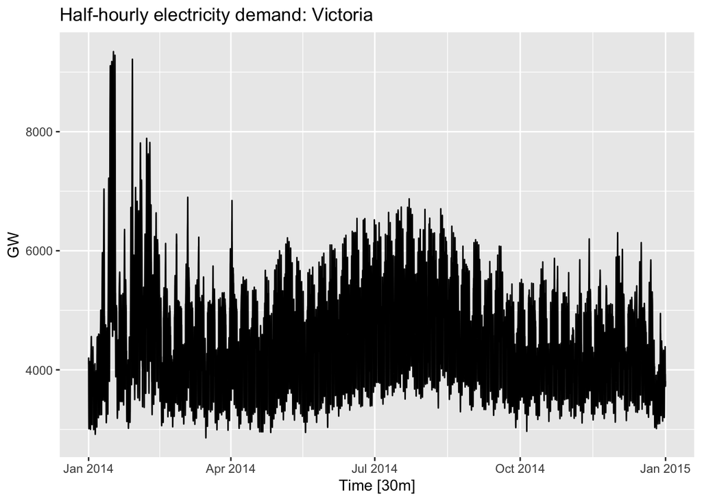

```r
library(ggplot2)
library(fpp3)  # Forecasting 패키지

a10 <- PBS %>%
  filter(ATC2 == "A10") %>%
  select(Month, Concession, Type, Cost) %>%
  summarise(TotalC = sum(Cost)) %>%
  mutate(Cost = TotalC / 1e6)

vic_elec |>
  filter(year(Time) == 2014) |>
  autoplot(Demand) +
  labs(y = "GW",
       title = "Half-hourly electricity demand: Victoria")
```

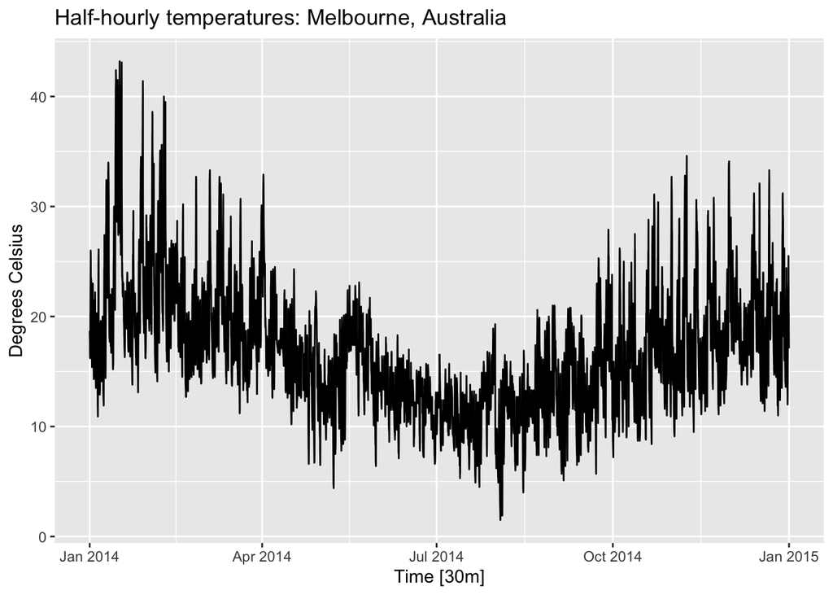

```r
vic_elec |>
  filter(year(Time) == 2014) |>
  autoplot(Temperature) +
  labs(y = "Degrees Celsius",
       title = "Half-hourly temperatures: Melbourne, Australia")
```

> 위 그래프는 2014년 동안의 전력 수요 및 기온 변화를 보여준다.

### 전력 수요와 기온 간 관계 분석 (산점도)

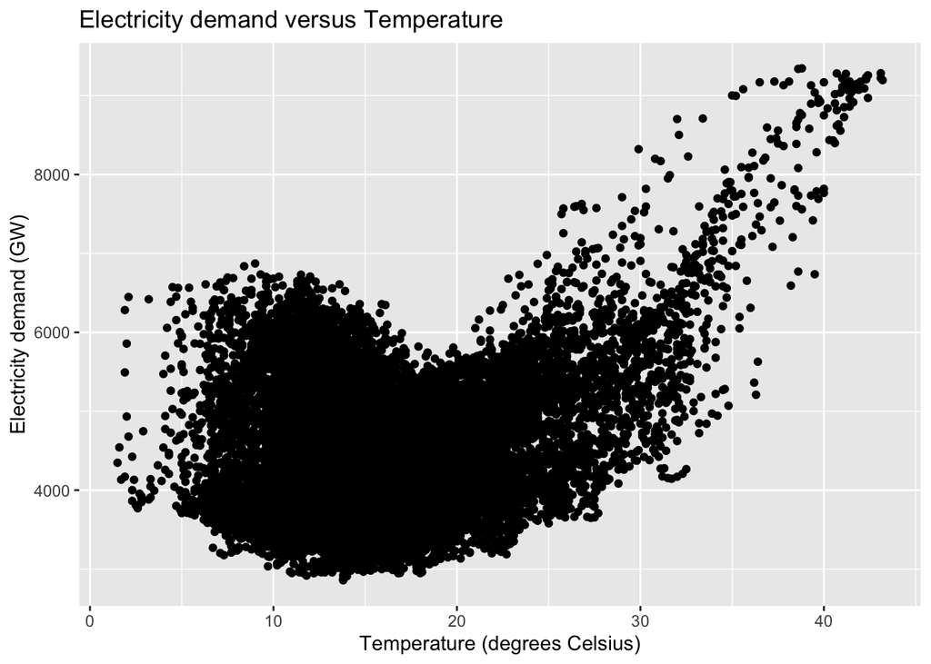

```r
vic_elec |>
  filter(year(Time) == 2014) |>
  ggplot(aes(x = Temperature, y = Demand)) +
  geom_point() +
  labs(title="Electricity demand versus Temperature",
       x = "Temperature (degrees Celsius)",
       y = "Electricity demand (GW)")
```

> 높은 기온과 낮은 기온 모두에서 전력 수요가 증가하는 패턴을 확인할 수 있다.

### 상관계수 계산

$$r = \frac{\sum (x_t - \bar{x})(y_t - \bar{y})}
{\sqrt{\sum (x_t - \bar{x})^2} \sqrt{\sum (y_t - \bar{y})^2}}.$$

```r
cor(vic_elec$Temperature, vic_elec$Demand, use = "complete.obs")
```

```
## [1] 0.2594956
```

> 상관계수는 0.26이지만, 비선형 관계가 더 강하게 나타남.

### 호주 국내 관광 데이터 분석 (산점도 행렬)

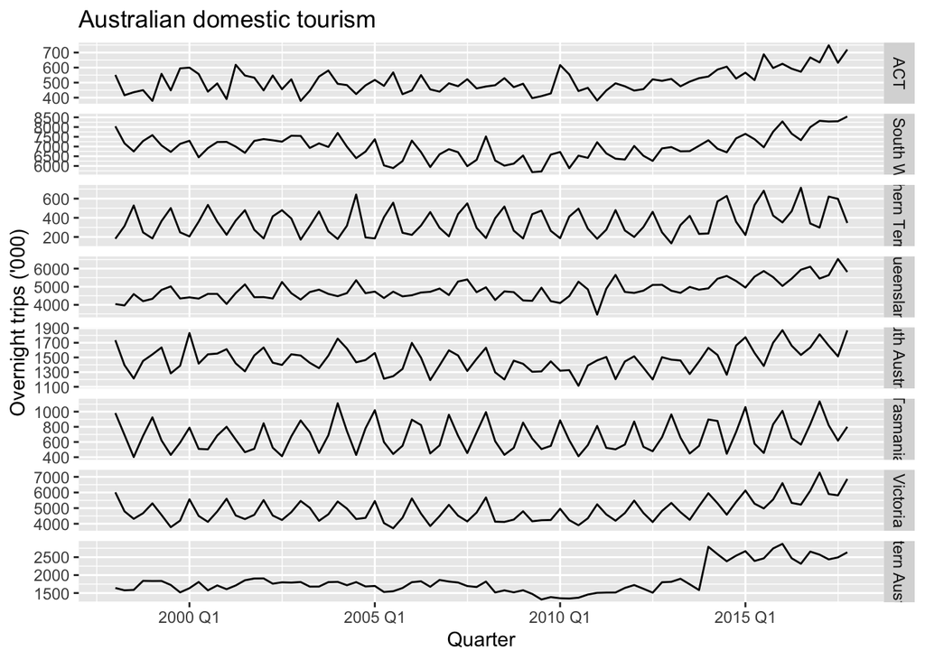

```r
visitors <- tourism |>
  group_by(State) |>
  summarise(Trips = sum(Trips))

visitors |>
  ggplot(aes(x = Quarter, y = Trips)) +
  geom_line() +
  facet_grid(vars(State), scales = "free_y") +
  labs(title = "Australian domestic tourism",
       y= "Overnight trips ('000)")
```

> 각 주에서 방문자 수의 계절성이 다르게 나타남.

#### (1) 산점도 행렬 생성

```r
library(GGally)
```

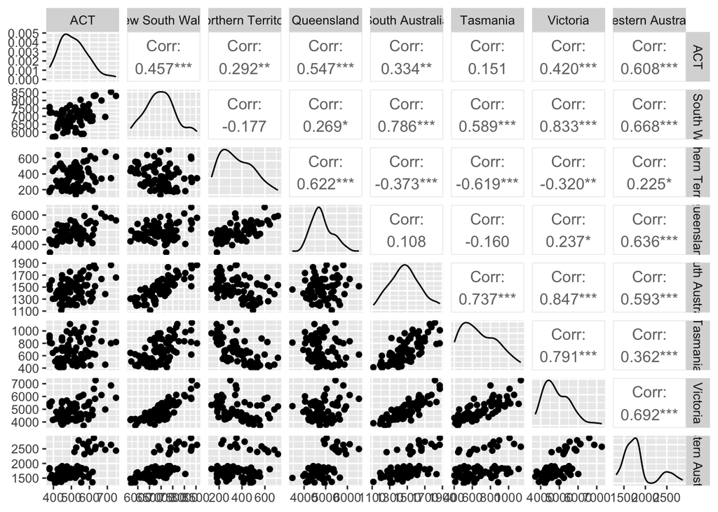

```r
visitors |>
  pivot_wider(values_from=Trips, names_from=State) |>
  GGally::ggpairs(columns = 2:9)
```

visitors 데이터 * key: State, * Index: Quarter

pivot_wider 사용후 key 사라지고, index만 남음. key에 해당하는 값들이 새로운 칼럼이 됨.

## 2.7 지연 그래프 (Lag plots)

### 분기별 맥주 생산량의 지연 그래프 분석

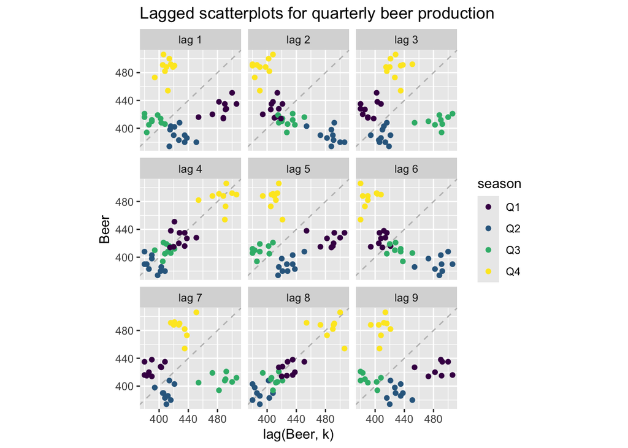

```r
library(ggplot2)
library(fpp3)  # Forecasting 패키지

recent_production <- aus_production |>
  filter(year(Quarter) >= 2000)

recent_production |>
  gg_lag(Beer, geom = "point") +
  labs(x = "lag(Beer, k)",
       title = "Lagged scatterplots for quarterly beer production")
```

> 색상은 각 분기를 나타내며, 특정 시차에서 상관관계를 분석할 수 있다.

### 지연 값에 따른 관계 해석

- **시차 4와 8(lags 4 and 8)**: 강한 양의 상관관계가 존재 → 데이터의 계절성 반영
- **시차 2와 6(lags 2 and 6)**: 음의 상관관계 → 4분기의 정점(Q4 peaks)과 2분기의 저점(Q2 troughs)이 비교됨

계절성을 확인하는 데 지연 그래프가 유용하게 활용될 수 있다.

## 2.8 자기상관 (Autocorrelation)

$$r_k = \frac{\sum_{t=k+1}^{T} (y_t - \bar{y})(y_{t-k} - \bar{y})}
{\sum_{t=1}^{T} (y_t - \bar{y})^2},$$

### 자기상관 개념 및 맥주 생산량 데이터 분석

```r
# 최근 맥주 생산량 데이터 필터링
recent_production <- aus_production |>
  filter(year(Quarter) >= 2000)

# 자기상관 함수(ACF) 계산
recent_production |> ACF(Beer, lag_max = 9)
```

```
## # A tsibble: 9 x 2 [1Q]
##        lag      acf
##   <cf_lag>    <dbl>
## 1       1Q -0.0530
## 2       2Q -0.758
## 3       3Q -0.0262
## 4       4Q  0.802
## 5       5Q -0.0775
## 6       6Q -0.657
## 7       7Q  0.00119
## 8       8Q  0.707
## 9       9Q -0.0888
```

맥주 생산량의 ACF 값을 계산하며, 계절성이 반영된 패턴을 확인할 수 있다.

### 맥주 생산량 ACF 그래프

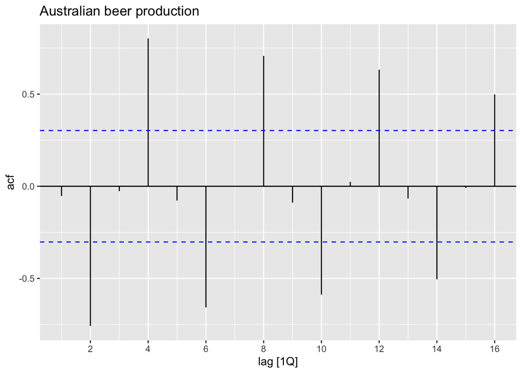

```r
recent_production |>
  ACF(Beer) |>
  autoplot() +
  labs(title="Australian beer production")
```

**해석:**

- **시차 4(lag 4)에서 가장 높은 양의 상관관계** → 1년 주기의 계절성 반영
- **시차 2(lag 2)에서 음의 상관관계** → 2분기 간격에서 피크와 저점 비교
- 파란색 점선: 상관관계의 유의성(significance) 여부 표시

### 트렌드와 계절성을 포함하는 ACF 분석

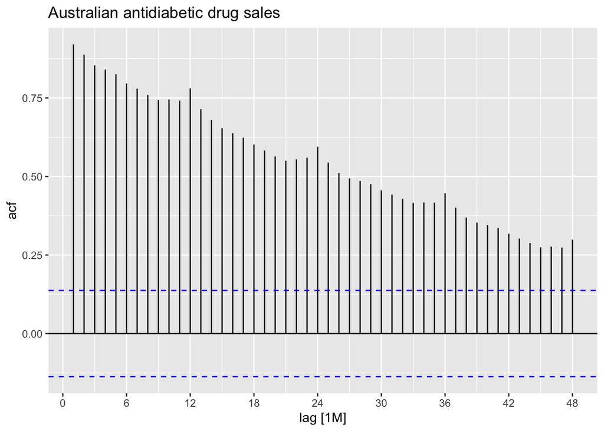

```r
# 항당뇨제 판매 데이터의 ACF 그래프

a10 |>
  ACF(Cost, lag_max = 48) |>
  autoplot() +
  labs(title="Australian antidiabetic drug sales")
```

**해석:**

- 느린 감소(Slow decrease) → 장기적인 **트렌드(trend)** 영향
- 곡선 형태(Scalloped shape) → **계절성(seasonality)** 영향

**결론:** ACF 그래프는 트렌드와 계절성을 파악하는 데 중요한 도구이다.

## 2.9 백색 잡음 (White Noise)

###. 백색 잡음 생성 및 시각화

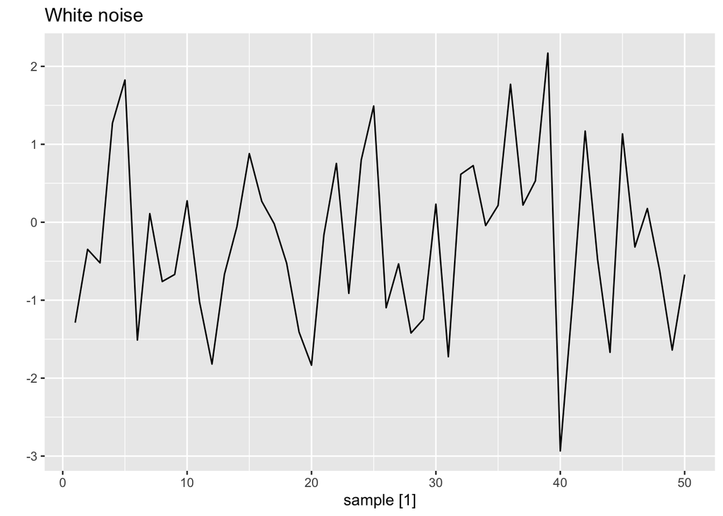

```r
# 백색 잡음 생성
set.seed(30)
y <- tsibble(sample = 1:50, wn = rnorm(50), index = sample)

# 백색 잡음 시계열 플로팅
y |> autoplot(wn) +
  labs(title = "White noise", y = "")
```

**설명:** 자기상관이 없는 무작위 시계열 데이터를 생성하여 시각화했다.

### 백색 잡음의 자기상관 함수(ACF) 분석

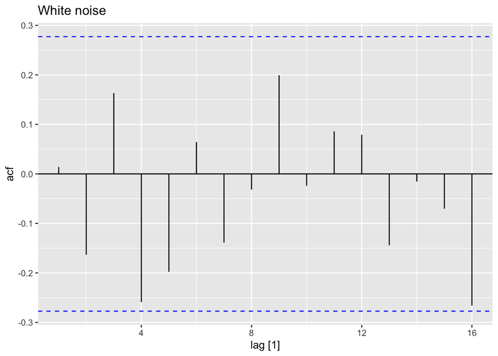

```r
# ACF 계산 및 플로팅
y |>
  ACF(wn) |>
  autoplot() +
  labs(title = "White noise")
```

**해석:**

- 백색 잡음의 경우, 자기상관 값이 모두 0에 가까워야 한다.
- 이론적으로 ACF 값의 95%가 범위 **±1.96 / sqrt(50) ≈ ±0.28** 내에 존재해야 한다.
- 모든 ACF 값이 해당 범위 내에 포함되므로, 이는 **백색 잡음 데이터**임을 확인할 수 있다.